# Risk Factor Analysis

## Outcome Variable

**Outcome Variable:** ever_stunted

## Predictor Variables

**Intervention Variable:** tr

**Adjustment Set:**

unadjusted

## Stratifying Variables

The analysis was stratified on these variable(s):

- agecat
- studyid
- country
- intXenwast

## Data Summary

| agecat | studyid | country | intXenwast | ever_stunted | n_cell | n |
| --- | --- | --- | --- | --- | --- | --- |
| 0-6 months | iLiNS_DYADM_LNS | MALAWI | 0_0-6 months | 0 | 32 | 40 |
| 0-6 months | iLiNS_DYADM_LNS | MALAWI | 0_0-6 months | 1 | 8 | 40 |
| 0-6 months | iLiNS_DYADM_LNS | MALAWI | 1_0-6 months | 0 | 1 | 1 |
| 0-6 months | iLiNS_DYADM_LNS | MALAWI | 1_0-6 months | 1 | 0 | 1 |
| 0-6 months | ki1000107-Serrinha-VitA | BRAZIL | 0_0-6 months | 0 | 9 | 10 |
| 0-6 months | ki1000107-Serrinha-VitA | BRAZIL | 0_0-6 months | 1 | 1 | 10 |
| 0-6 months | ki1000110-WASH-Bangladesh | BANGLADESH | 0_0-6 months | 0 | 199 | 221 |
| 0-6 months | ki1000110-WASH-Bangladesh | BANGLADESH | 0_0-6 months | 1 | 22 | 221 |
| 0-6 months | ki1000110-WASH-Bangladesh | BANGLADESH | 1_0-6 months | 0 | 10 | 11 |
| 0-6 months | ki1000110-WASH-Bangladesh | BANGLADESH | 1_0-6 months | 1 | 1 | 11 |
| 0-6 months | ki1000111-WASH-Kenya | KENYA | 0_0-6 months | 0 | 84 | 91 |
| 0-6 months | ki1000111-WASH-Kenya | KENYA | 0_0-6 months | 1 | 7 | 91 |
| 0-6 months | ki1000111-WASH-Kenya | KENYA | 1_0-6 months | 0 | 1 | 1 |
| 0-6 months | ki1000111-WASH-Kenya | KENYA | 1_0-6 months | 1 | 0 | 1 |
| 0-6 months | ki1000125-AgaKhanUniv | PAKISTAN | 0_0-6 months | 0 | 163 | 210 |
| 0-6 months | ki1000125-AgaKhanUniv | PAKISTAN | 0_0-6 months | 1 | 47 | 210 |
| 0-6 months | ki1000125-AgaKhanUniv | PAKISTAN | 1_0-6 months | 0 | 49 | 72 |
| 0-6 months | ki1000125-AgaKhanUniv | PAKISTAN | 1_0-6 months | 1 | 23 | 72 |
| 0-6 months | ki1000304-EU | INDIA | 0_0-6 months | 0 | 6 | 11 |
| 0-6 months | ki1000304-EU | INDIA | 0_0-6 months | 1 | 5 | 11 |
| 0-6 months | ki1000304-EU | INDIA | 1_0-6 months | 0 | 1 | 3 |
| 0-6 months | ki1000304-EU | INDIA | 1_0-6 months | 1 | 2 | 3 |
| 0-6 months | ki1000304-VITAMIN-A | INDIA | 0_0-6 months | 0 | 193 | 284 |
| 0-6 months | ki1000304-VITAMIN-A | INDIA | 0_0-6 months | 1 | 91 | 284 |
| 0-6 months | ki1000304-VITAMIN-A | INDIA | 1_0-6 months | 0 | 34 | 50 |
| 0-6 months | ki1000304-VITAMIN-A | INDIA | 1_0-6 months | 1 | 16 | 50 |
| 0-6 months | ki1000304-Vitamin-B12 | INDIA | 0_0-6 months | 0 | 1 | 1 |
| 0-6 months | ki1000304-Vitamin-B12 | INDIA | 0_0-6 months | 1 | 0 | 1 |
| 0-6 months | ki1000304-ZnMort | INDIA | 0_0-6 months | 0 | 100 | 165 |
| 0-6 months | ki1000304-ZnMort | INDIA | 0_0-6 months | 1 | 65 | 165 |

[output cut: 158 more lines]

The following strata were considered:

- agecat: 0-6 months, studyid: iLiNS_DYADM_LNS, country: MALAWI, intXenwast: 0_0-6 months
- agecat: 0-6 months, studyid: iLiNS_DYADM_LNS, country: MALAWI, intXenwast: 1_0-6 months
- agecat: 0-6 months, studyid: ki1000107-Serrinha-VitA, country: BRAZIL, intXenwast: 0_0-6 months
- agecat: 0-6 months, studyid: ki1000110-WASH-Bangladesh, country: BANGLADESH, intXenwast: 0_0-6 months
- agecat: 0-6 months, studyid: ki1000110-WASH-Bangladesh, country: BANGLADESH, intXenwast: 1_0-6 months
- agecat: 0-6 months, studyid: ki1000111-WASH-Kenya, country: KENYA, intXenwast: 0_0-6 months
- agecat: 0-6 months, studyid: ki1000111-WASH-Kenya, country: KENYA, intXenwast: 1_0-6 months
- agecat: 0-6 months, studyid: ki1000125-AgaKhanUniv, country: PAKISTAN, intXenwast: 0_0-6 months
- agecat: 0-6 months, studyid: ki1000125-AgaKhanUniv, country: PAKISTAN, intXenwast: 1_0-6 months
- agecat: 0-6 months, studyid: ki1000304-EU, country: INDIA, intXenwast: 0_0-6 months
- agecat: 0-6 months, studyid: ki1000304-EU, country: INDIA, intXenwast: 1_0-6 months
- agecat: 0-6 months, studyid: ki1000304-VITAMIN-A, country: INDIA, intXenwast: 0_0-6 months
- agecat: 0-6 months, studyid: ki1000304-VITAMIN-A, country: INDIA, intXenwast: 1_0-6 months
- agecat: 0-6 months, studyid: ki1000304-Vitamin-B12, country: INDIA, intXenwast: 0_0-6 months
- agecat: 0-6 months, studyid: ki1000304-ZnMort, country: INDIA, intXenwast: 0_0-6 months
- agecat: 0-6 months, studyid: ki1000304-ZnMort, country: INDIA, intXenwast: 1_0-6 months
- agecat: 0-6 months, studyid: ki1000304b-SAS-CompFeed, country: INDIA, intXenwast: 0_0-6 months
- agecat: 0-6 months, studyid: ki1000304b-SAS-CompFeed, country: INDIA, intXenwast: 1_0-6 months
- agecat: 0-6 months, studyid: ki1000304b-SAS-FoodSuppl, country: INDIA, intXenwast: 0_0-6 months
- agecat: 0-6 months, studyid: ki1000304b-SAS-FoodSuppl, country: INDIA, intXenwast: 1_0-6 months
- agecat: 0-6 months, studyid: ki1017093b-PROVIDE, country: BANGLADESH, intXenwast: 0_0-6 months
- agecat: 0-6 months, studyid: ki1017093b-PROVIDE, country: BANGLADESH, intXenwast: 1_0-6 months
- agecat: 0-6 months, studyid: ki1066203-TanzaniaChild2, country: TANZANIA, UNITED REPUBLIC OF, intXenwast: 0_0-6 months
- agecat: 0-6 months, studyid: ki1066203-TanzaniaChild2, country: TANZANIA, UNITED REPUBLIC OF, intXenwast: 1_0-6 months
- agecat: 0-6 months, studyid: ki1112895-Burkina Faso Zn, country: BURKINA FASO, intXenwast: 0_0-6 months
- agecat: 0-6 months, studyid: ki1112895-Burkina Faso Zn, country: BURKINA FASO, intXenwast: 1_0-6 months
- agecat: 0-6 months, studyid: ki1112895-Guatemala BSC, country: GUATEMALA, intXenwast: 0_0-6 months
- agecat: 0-6 months, studyid: ki1112895-Guatemala BSC, country: GUATEMALA, intXenwast: 1_0-6 months
- agecat: 0-6 months, studyid: ki1119695-PROBIT, country: BELARUS, intXenwast: 0_0-6 months
- agecat: 0-6 months, studyid: ki1119695-PROBIT, country: BELARUS, intXenwast: 1_0-6 months
- agecat: 0-6 months, studyid: ki1126311-ZVITAMBO, country: ZIMBABWE, intXenwast: 0_0-6 months
- agecat: 0-6 months, studyid: ki1126311-ZVITAMBO, country: ZIMBABWE, intXenwast: 1_0-6 months
- agecat: 0-6 months, studyid: ki1135781-COHORTS, country: GUATEMALA, intXenwast: 0_0-6 months
- agecat: 0-6 months, studyid: ki1135781-COHORTS, country: GUATEMALA, intXenwast: 1_0-6 months
- agecat: 0-6 months, studyid: ki1148112-iLiNS-DOSE, country: MALAWI, intXenwast: 0_0-6 months
- agecat: 0-6 months, studyid: ki1148112-iLiNS-DOSE, country: MALAWI, intXenwast: 1_0-6 months
- agecat: 0-6 months, studyid: ki1148112-iLiNS-DYAD-M, country: MALAWI, intXenwast: 0_0-6 months
- agecat: 0-6 months, studyid: ki1148112-iLiNS-DYAD-M, country: MALAWI, intXenwast: 1_0-6 months
- agecat: 0-6 months, studyid: ki1148112-LCNI-5, country: MALAWI, intXenwast: 0_0-6 months
- agecat: 0-6 months, studyid: ki1148112-LCNI-5, country: MALAWI, intXenwast: 1_0-6 months
- agecat: 0-6 months, studyid: kiGH5241-JiVitA-3, country: BANGLADESH, intXenwast: 0_0-6 months
- agecat: 0-6 months, studyid: kiGH5241-JiVitA-3, country: BANGLADESH, intXenwast: 1_0-6 months
- agecat: 0-6 months, studyid: kiGH5241-JiVitA-4, country: BANGLADESH, intXenwast: 0_0-6 months
- agecat: 0-6 months, studyid: kiGH5241-JiVitA-4, country: BANGLADESH, intXenwast: 1_0-6 months
- agecat: 6-24 months, studyid: iLiNS_DYADM_LNS, country: MALAWI, intXenwast: 0_6-24 months
- agecat: 6-24 months, studyid: iLiNS_DYADM_LNS, country: MALAWI, intXenwast: 1_6-24 months
- agecat: 6-24 months, studyid: iLiNS-Zinc_ZvLNS, country: BURKINA FASO, intXenwast: 0_6-24 months
- agecat: 6-24 months, studyid: iLiNS-Zinc_ZvLNS, country: BURKINA FASO, intXenwast: 1_6-24 months
- agecat: 6-24 months, studyid: ki1000107-Serrinha-VitA, country: BRAZIL, intXenwast: 0_6-24 months
- agecat: 6-24 months, studyid: ki1000107-Serrinha-VitA, country: BRAZIL, intXenwast: 1_6-24 months
- agecat: 6-24 months, studyid: ki1000110-WASH-Bangladesh, country: BANGLADESH, intXenwast: 0_6-24 months
- agecat: 6-24 months, studyid: ki1000110-WASH-Bangladesh, country: BANGLADESH, intXenwast: 1_6-24 months
- agecat: 6-24 months, studyid: ki1000111-WASH-Kenya, country: KENYA, intXenwast: 0_6-24 months
- agecat: 6-24 months, studyid: ki1000111-WASH-Kenya, country: KENYA, intXenwast: 1_6-24 months
- agecat: 6-24 months, studyid: ki1000125-AgaKhanUniv, country: PAKISTAN, intXenwast: 0_6-24 months
- agecat: 6-24 months, studyid: ki1000125-AgaKhanUniv, country: PAKISTAN, intXenwast: 1_6-24 months
- agecat: 6-24 months, studyid: ki1000304-EU, country: INDIA, intXenwast: 0_6-24 months
- agecat: 6-24 months, studyid: ki1000304-EU, country: INDIA, intXenwast: 1_6-24 months
- agecat: 6-24 months, studyid: ki1000304-VITAMIN-A, country: INDIA, intXenwast: 0_6-24 months
- agecat: 6-24 months, studyid: ki1000304-VITAMIN-A, country: INDIA, intXenwast: 1_6-24 months
- agecat: 6-24 months, studyid: ki1000304-Vitamin-B12, country: INDIA, intXenwast: 0_6-24 months
- agecat: 6-24 months, studyid: ki1000304-Vitamin-B12, country: INDIA, intXenwast: 1_6-24 months
- agecat: 6-24 months, studyid: ki1000304-ZnMort, country: INDIA, intXenwast: 0_6-24 months
- agecat: 6-24 months, studyid: ki1000304-ZnMort, country: INDIA, intXenwast: 1_6-24 months
- agecat: 6-24 months, studyid: ki1000304b-SAS-CompFeed, country: INDIA, intXenwast: 0_6-24 months
- agecat: 6-24 months, studyid: ki1000304b-SAS-CompFeed, country: INDIA, intXenwast: 1_6-24 months
- agecat: 6-24 months, studyid: ki1000304b-SAS-FoodSuppl, country: INDIA, intXenwast: 0_6-24 months
- agecat: 6-24 months, studyid: ki1000304b-SAS-FoodSuppl, country: INDIA, intXenwast: 1_6-24 months
- agecat: 6-24 months, studyid: ki1017093b-PROVIDE, country: BANGLADESH, intXenwast: 0_6-24 months
- agecat: 6-24 months, studyid: ki1017093b-PROVIDE, country: BANGLADESH, intXenwast: 1_6-24 months
- agecat: 6-24 months, studyid: ki1066203-TanzaniaChild2, country: TANZANIA, UNITED REPUBLIC OF, intXenwast: 0_6-24 months
- agecat: 6-24 months, studyid: ki1066203-TanzaniaChild2, country: TANZANIA, UNITED REPUBLIC OF, intXenwast: 1_6-24 months
- agecat: 6-24 months, studyid: ki1112895-Burkina Faso Zn, country: BURKINA FASO, intXenwast: 0_6-24 months
- agecat: 6-24 months, studyid: ki1112895-Burkina Faso Zn, country: BURKINA FASO, intXenwast: 1_6-24 months
- agecat: 6-24 months, studyid: ki1112895-Guatemala BSC, country: GUATEMALA, intXenwast: 0_6-24 months
- agecat: 6-24 months, studyid: ki1112895-Guatemala BSC, country: GUATEMALA, intXenwast: 1_6-24 months
- agecat: 6-24 months, studyid: ki1112895-iLiNS-Zinc, country: BURKINA FASO, intXenwast: 0_6-24 months
- agecat: 6-24 months, studyid: ki1112895-iLiNS-Zinc, country: BURKINA FASO, intXenwast: 1_6-24 months
- agecat: 6-24 months, studyid: ki1119695-PROBIT, country: BELARUS, intXenwast: 0_6-24 months
- agecat: 6-24 months, studyid: ki1119695-PROBIT, country: BELARUS, intXenwast: 1_6-24 months
- agecat: 6-24 months, studyid: ki1126311-ZVITAMBO, country: ZIMBABWE, intXenwast: 0_6-24 months
- agecat: 6-24 months, studyid: ki1126311-ZVITAMBO, country: ZIMBABWE, intXenwast: 1_6-24 months
- agecat: 6-24 months, studyid: ki1135781-COHORTS, country: GUATEMALA, intXenwast: 0_6-24 months
- agecat: 6-24 months, studyid: ki1135781-COHORTS, country: GUATEMALA, intXenwast: 1_6-24 months
- agecat: 6-24 months, studyid: ki1148112-iLiNS-DOSE, country: MALAWI, intXenwast: 0_6-24 months
- agecat: 6-24 months, studyid: ki1148112-iLiNS-DOSE, country: MALAWI, intXenwast: 1_6-24 months
- agecat: 6-24 months, studyid: ki1148112-iLiNS-DYAD-M, country: MALAWI, intXenwast: 0_6-24 months
- agecat: 6-24 months, studyid: ki1148112-iLiNS-DYAD-M, country: MALAWI, intXenwast: 1_6-24 months
- agecat: 6-24 months, studyid: ki1148112-LCNI-5, country: MALAWI, intXenwast: 0_6-24 months
- agecat: 6-24 months, studyid: ki1148112-LCNI-5, country: MALAWI, intXenwast: 1_6-24 months
- agecat: 6-24 months, studyid: kiGH5241-JiVitA-3, country: BANGLADESH, intXenwast: 0_6-24 months
- agecat: 6-24 months, studyid: kiGH5241-JiVitA-3, country: BANGLADESH, intXenwast: 1_6-24 months
- agecat: 6-24 months, studyid: kiGH5241-JiVitA-4, country: BANGLADESH, intXenwast: 0_6-24 months
- agecat: 6-24 months, studyid: kiGH5241-JiVitA-4, country: BANGLADESH, intXenwast: 1_6-24 months

### Dropped Strata

Some strata were dropped due to rare outcomes:

- agecat: 0-6 months, studyid: iLiNS_DYADM_LNS, country: MALAWI, intXenwast: 1_0-6 months
- agecat: 0-6 months, studyid: ki1000107-Serrinha-VitA, country: BRAZIL, intXenwast: 0_0-6 months
- agecat: 0-6 months, studyid: ki1000110-WASH-Bangladesh, country: BANGLADESH, intXenwast: 1_0-6 months
- agecat: 0-6 months, studyid: ki1000111-WASH-Kenya, country: KENYA, intXenwast: 1_0-6 months
- agecat: 0-6 months, studyid: ki1000304-EU, country: INDIA, intXenwast: 1_0-6 months
- agecat: 0-6 months, studyid: ki1000304-Vitamin-B12, country: INDIA, intXenwast: 0_0-6 months
- agecat: 0-6 months, studyid: ki1112895-Burkina Faso Zn, country: BURKINA FASO, intXenwast: 0_0-6 months
- agecat: 0-6 months, studyid: ki1112895-Burkina Faso Zn, country: BURKINA FASO, intXenwast: 1_0-6 months
- agecat: 0-6 months, studyid: ki1112895-Guatemala BSC, country: GUATEMALA, intXenwast: 1_0-6 months
- agecat: 0-6 months, studyid: ki1148112-iLiNS-DYAD-M, country: MALAWI, intXenwast: 1_0-6 months
- agecat: 0-6 months, studyid: ki1148112-LCNI-5, country: MALAWI, intXenwast: 1_0-6 months
- agecat: 6-24 months, studyid: ki1000107-Serrinha-VitA, country: BRAZIL, intXenwast: 1_6-24 months
- agecat: 6-24 months, studyid: ki1112895-Guatemala BSC, country: GUATEMALA, intXenwast: 1_6-24 months

## Methods Detail

We’re interested in the causal parameters $E[Y_a]$ for all values of $a \in \mathcal{A}$. These parameters represent the mean outcome if, possibly contrary to fact, we intervened to set all units to have $A=a$. Under the randomization and positivity assumptions, these are identified by the statistical parameters $\psi_a=E_W[E_{Y|A,W}(Y|A=a,W)]$. In addition, we’re interested in the mean of $Y$, $E[Y]$ under no intervention (the observed mean). We will estimate these parameters by using SuperLearner to fit the relevant likelihood factors – $E_{Y|A,W}(Y|A=a,W)$ and $p(A=a|W)$, and then updating our likelihood fit using a joint TMLE.

For unadjusted analyses ($W=\{\}$), initial likelihoods were estimated using Lrnr_glm to estimate the simple $E(Y|A)$ and Lrnr_mean to estimate $p(A)$. For adjusted analyses, a small library containing Lrnr_glmnet, Lrnr_xgboost, and Lrnr_mean was used.

Having estimated these parameters, we will then use the delta method to estimate relative risks and attributable risks relative to a prespecified baseline level of $A$.

# Results Detail

## Results Plots

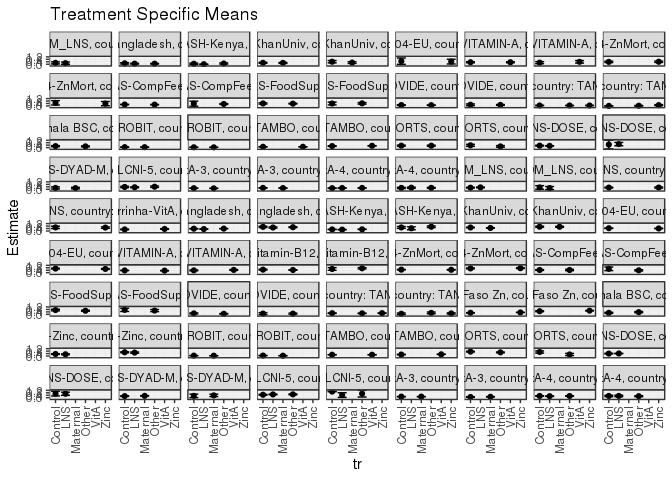

[figure not shown]

[figure not shown]

[figure not shown]

## Results Table

### Parameter: TSM

| agecat | studyid | country | intXenwast | intervention_level | baseline_level | estimate | ci_lower | ci_upper |
| --- | --- | --- | --- | --- | --- | --- | --- | --- |
| 0-6 months | iLiNS_DYADM_LNS | MALAWI | 0_0-6 months | Control | NA | 0.2173913 | 0.0466749 | 0.3881077 |
| 0-6 months | iLiNS_DYADM_LNS | MALAWI | 0_0-6 months | LNS | NA | 0.1764706 | -0.0070552 | 0.3599964 |
| 0-6 months | ki1000110-WASH-Bangladesh | BANGLADESH | 0_0-6 months | Control | NA | 0.1428571 | 0.0367888 | 0.2489255 |
| 0-6 months | ki1000110-WASH-Bangladesh | BANGLADESH | 0_0-6 months | LNS | NA | 0.0909091 | 0.0213957 | 0.1604224 |
| 0-6 months | ki1000110-WASH-Bangladesh | BANGLADESH | 0_0-6 months | Other | NA | 0.0884956 | 0.0360107 | 0.1409804 |
| 0-6 months | ki1000111-WASH-Kenya | KENYA | 0_0-6 months | Control | NA | 0.0769231 | -0.0260700 | 0.1799162 |
| 0-6 months | ki1000111-WASH-Kenya | KENYA | 0_0-6 months | LNS | NA | 0.0000000 | 0.0000000 | 0.0000000 |
| 0-6 months | ki1000111-WASH-Kenya | KENYA | 0_0-6 months | Other | NA | 0.1190476 | 0.0205650 | 0.2175302 |
| 0-6 months | ki1000125-AgaKhanUniv | PAKISTAN | 0_0-6 months | Control | NA | 0.2314815 | 0.1517448 | 0.3112181 |
| 0-6 months | ki1000125-AgaKhanUniv | PAKISTAN | 0_0-6 months | Maternal | NA | 0.2156863 | 0.1356769 | 0.2956956 |
| 0-6 months | ki1000125-AgaKhanUniv | PAKISTAN | 1_0-6 months | Control | NA | 0.4074074 | 0.2207712 | 0.5940436 |
| 0-6 months | ki1000125-AgaKhanUniv | PAKISTAN | 1_0-6 months | Maternal | NA | 0.2666667 | 0.1365557 | 0.3967777 |
| 0-6 months | ki1000304-EU | INDIA | 0_0-6 months | Control | NA | 0.5000000 | -0.0139069 | 1.0139069 |
| 0-6 months | ki1000304-EU | INDIA | 0_0-6 months | Zinc | NA | 0.4285714 | 0.0440788 | 0.8130640 |
| 0-6 months | ki1000304-VITAMIN-A | INDIA | 0_0-6 months | Control | NA | 0.3194444 | 0.2431554 | 0.3957335 |
| 0-6 months | ki1000304-VITAMIN-A | INDIA | 0_0-6 months | VitA | NA | 0.3214286 | 0.2439307 | 0.3989265 |
| 0-6 months | ki1000304-VITAMIN-A | INDIA | 1_0-6 months | Control | NA | 0.2592593 | 0.0922835 | 0.4262350 |
| 0-6 months | ki1000304-VITAMIN-A | INDIA | 1_0-6 months | VitA | NA | 0.3913043 | 0.1898259 | 0.5927828 |
| 0-6 months | ki1000304-ZnMort | INDIA | 0_0-6 months | Control | NA | 0.3827160 | 0.2765449 | 0.4888872 |
| 0-6 months | ki1000304-ZnMort | INDIA | 0_0-6 months | Zinc | NA | 0.4047619 | 0.2994752 | 0.5100486 |
| 0-6 months | ki1000304-ZnMort | INDIA | 1_0-6 months | Control | NA | 0.5000000 | 0.1421612 | 0.8578388 |
| 0-6 months | ki1000304-ZnMort | INDIA | 1_0-6 months | Zinc | NA | 0.3750000 | 0.0285240 | 0.7214760 |
| 0-6 months | ki1000304b-SAS-CompFeed | INDIA | 0_0-6 months | Control | NA | 0.2236842 | 0.1882370 | 0.2591314 |
| 0-6 months | ki1000304b-SAS-CompFeed | INDIA | 0_0-6 months | Other | NA | 0.2078313 | 0.1722482 | 0.2434144 |
| 0-6 months | ki1000304b-SAS-CompFeed | INDIA | 1_0-6 months | Control | NA | 0.3666667 | -0.0388576 | 0.7721909 |
| 0-6 months | ki1000304b-SAS-CompFeed | INDIA | 1_0-6 months | Other | NA | 0.3125000 | 0.2440564 | 0.3809436 |
| 0-6 months | ki1000304b-SAS-FoodSuppl | INDIA | 0_0-6 months | Control | NA | 0.4022989 | 0.2991063 | 0.5054914 |
| 0-6 months | ki1000304b-SAS-FoodSuppl | INDIA | 0_0-6 months | Other | NA | 0.3665339 | 0.3068340 | 0.4262337 |
| 0-6 months | ki1000304b-SAS-FoodSuppl | INDIA | 1_0-6 months | Control | NA | 0.3888889 | 0.1622228 | 0.6155550 |
| 0-6 months | ki1000304b-SAS-FoodSuppl | INDIA | 1_0-6 months | Other | NA | 0.4166667 | 0.2911136 | 0.5422197 |

[output cut: 149 more lines]

### Parameter: E(Y)

| agecat | studyid | country | intXenwast | intervention_level | baseline_level | estimate | ci_lower | ci_upper |
| --- | --- | --- | --- | --- | --- | --- | --- | --- |
| 0-6 months | iLiNS_DYADM_LNS | MALAWI | 0_0-6 months | NA | NA | 0.2000000 | 0.0744618 | 0.3255382 |
| 0-6 months | ki1000110-WASH-Bangladesh | BANGLADESH | 0_0-6 months | NA | NA | 0.0995475 | 0.0599851 | 0.1391099 |
| 0-6 months | ki1000111-WASH-Kenya | KENYA | 0_0-6 months | NA | NA | 0.0769231 | 0.0218710 | 0.1319752 |
| 0-6 months | ki1000125-AgaKhanUniv | PAKISTAN | 0_0-6 months | NA | NA | 0.2238095 | 0.1673030 | 0.2803160 |
| 0-6 months | ki1000125-AgaKhanUniv | PAKISTAN | 1_0-6 months | NA | NA | 0.3194444 | 0.2109897 | 0.4278991 |
| 0-6 months | ki1000304-EU | INDIA | 0_0-6 months | NA | NA | 0.4545455 | 0.1459312 | 0.7631597 |
| 0-6 months | ki1000304-VITAMIN-A | INDIA | 0_0-6 months | NA | NA | 0.3204225 | 0.2660555 | 0.3747896 |
| 0-6 months | ki1000304-VITAMIN-A | INDIA | 1_0-6 months | NA | NA | 0.3200000 | 0.1893891 | 0.4506109 |
| 0-6 months | ki1000304-ZnMort | INDIA | 0_0-6 months | NA | NA | 0.3939394 | 0.3191571 | 0.4687217 |
| 0-6 months | ki1000304-ZnMort | INDIA | 1_0-6 months | NA | NA | 0.4375000 | 0.1864543 | 0.6885457 |
| 0-6 months | ki1000304b-SAS-CompFeed | INDIA | 0_0-6 months | NA | NA | 0.2154088 | 0.1893844 | 0.2414332 |
| 0-6 months | ki1000304b-SAS-CompFeed | INDIA | 1_0-6 months | NA | NA | 0.3333333 | 0.1719543 | 0.4947124 |
| 0-6 months | ki1000304b-SAS-FoodSuppl | INDIA | 0_0-6 months | NA | NA | 0.3757396 | 0.3240314 | 0.4274479 |
| 0-6 months | ki1000304b-SAS-FoodSuppl | INDIA | 1_0-6 months | NA | NA | 0.4102564 | 0.3003907 | 0.5201221 |
| 0-6 months | ki1017093b-PROVIDE | BANGLADESH | 0_0-6 months | NA | NA | 0.1244980 | 0.0954725 | 0.1535235 |
| 0-6 months | ki1017093b-PROVIDE | BANGLADESH | 1_0-6 months | NA | NA | 0.1641791 | 0.1012230 | 0.2271352 |
| 0-6 months | ki1066203-TanzaniaChild2 | TANZANIA, UNITED REPUBLIC OF | 0_0-6 months | NA | NA | 0.0705434 | 0.0595839 | 0.0815029 |
| 0-6 months | ki1066203-TanzaniaChild2 | TANZANIA, UNITED REPUBLIC OF | 1_0-6 months | NA | NA | 0.0708661 | 0.0260617 | 0.1156706 |
| 0-6 months | ki1112895-Guatemala BSC | GUATEMALA | 0_0-6 months | NA | NA | 0.2184874 | 0.1658790 | 0.2710958 |
| 0-6 months | ki1119695-PROBIT | BELARUS | 0_0-6 months | NA | NA | 0.0694529 | 0.0546491 | 0.0842568 |
| 0-6 months | ki1119695-PROBIT | BELARUS | 1_0-6 months | NA | NA | 0.0453074 | 0.0304788 | 0.0601360 |
| 0-6 months | ki1126311-ZVITAMBO | ZIMBABWE | 0_0-6 months | NA | NA | 0.1352323 | 0.1273503 | 0.1431143 |
| 0-6 months | ki1126311-ZVITAMBO | ZIMBABWE | 1_0-6 months | NA | NA | 0.2815675 | 0.2578119 | 0.3053231 |
| 0-6 months | ki1135781-COHORTS | GUATEMALA | 0_0-6 months | NA | NA | 0.3091787 | 0.2460682 | 0.3722893 |
| 0-6 months | ki1135781-COHORTS | GUATEMALA | 1_0-6 months | NA | NA | 0.2816901 | 0.1763144 | 0.3870659 |
| 0-6 months | ki1148112-iLiNS-DOSE | MALAWI | 0_0-6 months | NA | NA | 0.2870449 | 0.2612334 | 0.3128564 |
| 0-6 months | ki1148112-iLiNS-DOSE | MALAWI | 1_0-6 months | NA | NA | 0.5625000 | 0.3114543 | 0.8135457 |
| 0-6 months | ki1148112-iLiNS-DYAD-M | MALAWI | 0_0-6 months | NA | NA | 0.2000000 | 0.1020018 | 0.2979982 |
| 0-6 months | ki1148112-LCNI-5 | MALAWI | 0_0-6 months | NA | NA | 0.3619403 | 0.3042980 | 0.4195826 |
| 0-6 months | kiGH5241-JiVitA-3 | BANGLADESH | 0_0-6 months | NA | NA | 0.1621079 | 0.1555101 | 0.1687057 |

[output cut: 51 more lines]

### Parameter: RR

| agecat | studyid | country | intXenwast | intervention_level | baseline_level | estimate | ci_lower | ci_upper |
| --- | --- | --- | --- | --- | --- | --- | --- | --- |
| 0-6 months | iLiNS_DYADM_LNS | MALAWI | 0_0-6 months | Control | Control | 1.0000000 | 1.0000000 | 1.0000000 |
| 0-6 months | iLiNS_DYADM_LNS | MALAWI | 0_0-6 months | LNS | Control | 0.8117647 | 0.2205320 | 2.9880558 |
| 0-6 months | ki1000110-WASH-Bangladesh | BANGLADESH | 0_0-6 months | Control | Control | 1.0000000 | 1.0000000 | 1.0000000 |
| 0-6 months | ki1000110-WASH-Bangladesh | BANGLADESH | 0_0-6 months | LNS | Control | 0.6363636 | 0.2191938 | 1.8474914 |
| 0-6 months | ki1000110-WASH-Bangladesh | BANGLADESH | 0_0-6 months | Other | Control | 0.6194690 | 0.2395090 | 1.6022025 |
| 0-6 months | ki1000111-WASH-Kenya | KENYA | 0_0-6 months | Control | Control | 1.0000000 | 1.0000000 | 1.0000000 |
| 0-6 months | ki1000111-WASH-Kenya | KENYA | 0_0-6 months | LNS | Control | 0.0000000 | 0.0000000 | 0.0000002 |
| 0-6 months | ki1000111-WASH-Kenya | KENYA | 0_0-6 months | Other | Control | 1.5476190 | 0.3207348 | 7.4676162 |
| 0-6 months | ki1000125-AgaKhanUniv | PAKISTAN | 0_0-6 months | Control | Control | 1.0000000 | 1.0000000 | 1.0000000 |
| 0-6 months | ki1000125-AgaKhanUniv | PAKISTAN | 0_0-6 months | Maternal | Control | 0.9317647 | 0.5616389 | 1.5458073 |
| 0-6 months | ki1000125-AgaKhanUniv | PAKISTAN | 1_0-6 months | Control | Control | 1.0000000 | 1.0000000 | 1.0000000 |
| 0-6 months | ki1000125-AgaKhanUniv | PAKISTAN | 1_0-6 months | Maternal | Control | 0.6545455 | 0.3351806 | 1.2782056 |
| 0-6 months | ki1000304-EU | INDIA | 0_0-6 months | Control | Control | 1.0000000 | 1.0000000 | 1.0000000 |
| 0-6 months | ki1000304-EU | INDIA | 0_0-6 months | Zinc | Control | 0.8571429 | 0.2190539 | 3.3539409 |
| 0-6 months | ki1000304-VITAMIN-A | INDIA | 0_0-6 months | Control | Control | 1.0000000 | 1.0000000 | 1.0000000 |
| 0-6 months | ki1000304-VITAMIN-A | INDIA | 0_0-6 months | VitA | Control | 1.0062112 | 0.7166495 | 1.4127700 |
| 0-6 months | ki1000304-VITAMIN-A | INDIA | 1_0-6 months | Control | Control | 1.0000000 | 1.0000000 | 1.0000000 |
| 0-6 months | ki1000304-VITAMIN-A | INDIA | 1_0-6 months | VitA | Control | 1.5093168 | 0.6617219 | 3.4425897 |
| 0-6 months | ki1000304-ZnMort | INDIA | 0_0-6 months | Control | Control | 1.0000000 | 1.0000000 | 1.0000000 |
| 0-6 months | ki1000304-ZnMort | INDIA | 0_0-6 months | Zinc | Control | 1.0576037 | 0.7230436 | 1.5469683 |
| 0-6 months | ki1000304-ZnMort | INDIA | 1_0-6 months | Control | Control | 1.0000000 | 1.0000000 | 1.0000000 |
| 0-6 months | ki1000304-ZnMort | INDIA | 1_0-6 months | Zinc | Control | 0.7500000 | 0.2330788 | 2.4133472 |
| 0-6 months | ki1000304b-SAS-CompFeed | INDIA | 0_0-6 months | Control | Control | 1.0000000 | 1.0000000 | 1.0000000 |
| 0-6 months | ki1000304b-SAS-CompFeed | INDIA | 0_0-6 months | Other | Control | 0.9291283 | 0.7355651 | 1.1736274 |
| 0-6 months | ki1000304b-SAS-CompFeed | INDIA | 1_0-6 months | Control | Control | 1.0000000 | 1.0000000 | 1.0000000 |
| 0-6 months | ki1000304b-SAS-CompFeed | INDIA | 1_0-6 months | Other | Control | 0.8522727 | 0.2749403 | 2.6419149 |
| 0-6 months | ki1000304b-SAS-FoodSuppl | INDIA | 0_0-6 months | Control | Control | 1.0000000 | 1.0000000 | 1.0000000 |
| 0-6 months | ki1000304b-SAS-FoodSuppl | INDIA | 0_0-6 months | Other | Control | 0.9110985 | 0.6723648 | 1.2345983 |
| 0-6 months | ki1000304b-SAS-FoodSuppl | INDIA | 1_0-6 months | Control | Control | 1.0000000 | 1.0000000 | 1.0000000 |
| 0-6 months | ki1000304b-SAS-FoodSuppl | INDIA | 1_0-6 months | Other | Control | 1.0714286 | 0.5559113 | 2.0650043 |

[output cut: 149 more lines]

### Parameter: PAR

| agecat | studyid | country | intXenwast | intervention_level | baseline_level | estimate | ci_lower | ci_upper |
| --- | --- | --- | --- | --- | --- | --- | --- | --- |
| 0-6 months | iLiNS_DYADM_LNS | MALAWI | 0_0-6 months | Control | NA | -0.0173913 | -0.1241069 | 0.0893243 |
| 0-6 months | ki1000110-WASH-Bangladesh | BANGLADESH | 0_0-6 months | Control | NA | -0.0433096 | -0.1357189 | 0.0490996 |
| 0-6 months | ki1000111-WASH-Kenya | KENYA | 0_0-6 months | Control | NA | 0.0000000 | -0.0870451 | 0.0870451 |
| 0-6 months | ki1000125-AgaKhanUniv | PAKISTAN | 0_0-6 months | Control | NA | -0.0076720 | -0.0625475 | 0.0472036 |
| 0-6 months | ki1000125-AgaKhanUniv | PAKISTAN | 1_0-6 months | Control | NA | -0.0879630 | -0.2310388 | 0.0551129 |
| 0-6 months | ki1000304-EU | INDIA | 0_0-6 months | Control | NA | -0.0454545 | -0.4544413 | 0.3635322 |
| 0-6 months | ki1000304-VITAMIN-A | INDIA | 0_0-6 months | Control | NA | 0.0009781 | -0.0526298 | 0.0545860 |
| 0-6 months | ki1000304-VITAMIN-A | INDIA | 1_0-6 months | Control | NA | 0.0607407 | -0.0610326 | 0.1825141 |
| 0-6 months | ki1000304-ZnMort | INDIA | 0_0-6 months | Control | NA | 0.0112233 | -0.0649170 | 0.0873636 |
| 0-6 months | ki1000304-ZnMort | INDIA | 1_0-6 months | Control | NA | -0.0625000 | -0.3135457 | 0.1885457 |
| 0-6 months | ki1000304b-SAS-CompFeed | INDIA | 0_0-6 months | Control | NA | -0.0082754 | -0.0356485 | 0.0190977 |
| 0-6 months | ki1000304b-SAS-CompFeed | INDIA | 1_0-6 months | Control | NA | -0.0333333 | -0.2903898 | 0.2237231 |
| 0-6 months | ki1000304b-SAS-FoodSuppl | INDIA | 0_0-6 months | Control | NA | -0.0265592 | -0.1151062 | 0.0619878 |
| 0-6 months | ki1000304b-SAS-FoodSuppl | INDIA | 1_0-6 months | Control | NA | 0.0213675 | -0.1779696 | 0.2207047 |
| 0-6 months | ki1017093b-PROVIDE | BANGLADESH | 0_0-6 months | Control | NA | -0.0108404 | -0.0600364 | 0.0383557 |
| 0-6 months | ki1017093b-PROVIDE | BANGLADESH | 1_0-6 months | Control | NA | -0.0233209 | -0.1398921 | 0.0932503 |
| 0-6 months | ki1066203-TanzaniaChild2 | TANZANIA, UNITED REPUBLIC OF | 0_0-6 months | Control | NA | -0.0029030 | -0.0219643 | 0.0161584 |
| 0-6 months | ki1066203-TanzaniaChild2 | TANZANIA, UNITED REPUBLIC OF | 1_0-6 months | Control | NA | 0.0708661 | 0.0260617 | 0.1156706 |
| 0-6 months | ki1112895-Guatemala BSC | GUATEMALA | 0_0-6 months | Control | NA | -0.0188007 | -0.0718796 | 0.0342781 |
| 0-6 months | ki1119695-PROBIT | BELARUS | 0_0-6 months | Control | NA | -0.0035872 | -0.0193109 | 0.0121365 |
| 0-6 months | ki1119695-PROBIT | BELARUS | 1_0-6 months | Control | NA | -0.0035028 | -0.0170150 | 0.0100094 |
| 0-6 months | ki1126311-ZVITAMBO | ZIMBABWE | 0_0-6 months | Control | NA | 0.0014530 | -0.0122281 | 0.0151342 |
| 0-6 months | ki1126311-ZVITAMBO | ZIMBABWE | 1_0-6 months | Control | NA | 0.0308788 | -0.0079228 | 0.0696804 |
| 0-6 months | ki1135781-COHORTS | GUATEMALA | 0_0-6 months | Control | NA | -0.0039526 | -0.0698886 | 0.0619835 |
| 0-6 months | ki1135781-COHORTS | GUATEMALA | 1_0-6 months | Control | NA | -0.0897384 | -0.1968371 | 0.0173602 |
| 0-6 months | ki1148112-iLiNS-DOSE | MALAWI | 0_0-6 months | Control | NA | -0.0301594 | -0.0912576 | 0.0309388 |
| 0-6 months | ki1148112-iLiNS-DOSE | MALAWI | 1_0-6 months | Control | NA | 0.0625000 | -0.6062076 | 0.7312076 |
| 0-6 months | ki1148112-iLiNS-DYAD-M | MALAWI | 0_0-6 months | Control | NA | -0.0173913 | -0.1517025 | 0.1169199 |
| 0-6 months | ki1148112-LCNI-5 | MALAWI | 0_0-6 months | Control | NA | -0.0168476 | -0.1183305 | 0.0846354 |
| 0-6 months | kiGH5241-JiVitA-3 | BANGLADESH | 0_0-6 months | Control | NA | -0.0135620 | -0.0203700 | -0.0067541 |

[output cut: 51 more lines]

### Parameter: PAF

| agecat | studyid | country | intXenwast | intervention_level | baseline_level | estimate | ci_lower | ci_upper |
| --- | --- | --- | --- | --- | --- | --- | --- | --- |
| 0-6 months | iLiNS_DYADM_LNS | MALAWI | 0_0-6 months | Control | NA | -0.0869565 | -0.7737561 | 0.3339138 |
| 0-6 months | ki1000110-WASH-Bangladesh | BANGLADESH | 0_0-6 months | Control | NA | -0.4350649 | -1.7192838 | 0.2426640 |
| 0-6 months | ki1000111-WASH-Kenya | KENYA | 0_0-6 months | Control | NA | 0.0000000 | -2.1005692 | 0.6774786 |
| 0-6 months | ki1000125-AgaKhanUniv | PAKISTAN | 0_0-6 months | Control | NA | -0.0342790 | -0.3108915 | 0.1839653 |
| 0-6 months | ki1000125-AgaKhanUniv | PAKISTAN | 1_0-6 months | Control | NA | -0.2753623 | -0.8147041 | 0.1036836 |
| 0-6 months | ki1000304-EU | INDIA | 0_0-6 months | Control | NA | -0.1000000 | -1.4973294 | 0.5154824 |
| 0-6 months | ki1000304-VITAMIN-A | INDIA | 0_0-6 months | Control | NA | 0.0030525 | -0.1791087 | 0.1570715 |
| 0-6 months | ki1000304-VITAMIN-A | INDIA | 1_0-6 months | Control | NA | 0.1898148 | -0.2928994 | 0.4923039 |
| 0-6 months | ki1000304-ZnMort | INDIA | 0_0-6 months | Control | NA | 0.0284900 | -0.1853807 | 0.2037734 |
| 0-6 months | ki1000304-ZnMort | INDIA | 1_0-6 months | Control | NA | -0.1428571 | -0.8957071 | 0.3110104 |
| 0-6 months | ki1000304b-SAS-CompFeed | INDIA | 0_0-6 months | Control | NA | -0.0384172 | -0.1743149 | 0.0817537 |
| 0-6 months | ki1000304b-SAS-CompFeed | INDIA | 1_0-6 months | Control | NA | -0.1000000 | -1.1347616 | 0.4331920 |
| 0-6 months | ki1000304b-SAS-FoodSuppl | INDIA | 0_0-6 months | Control | NA | -0.0706851 | -0.3343648 | 0.1408896 |
| 0-6 months | ki1000304b-SAS-FoodSuppl | INDIA | 1_0-6 months | Control | NA | 0.0520833 | -0.5827437 | 0.4322858 |
| 0-6 months | ki1017093b-PROVIDE | BANGLADESH | 0_0-6 months | Control | NA | -0.0870725 | -0.5630838 | 0.2439774 |
| 0-6 months | ki1017093b-PROVIDE | BANGLADESH | 1_0-6 months | Control | NA | -0.1420455 | -1.1244742 | 0.3860750 |
| 0-6 months | ki1066203-TanzaniaChild2 | TANZANIA, UNITED REPUBLIC OF | 0_0-6 months | Control | NA | -0.0411513 | -0.3495795 | 0.1967897 |
| 0-6 months | ki1066203-TanzaniaChild2 | TANZANIA, UNITED REPUBLIC OF | 1_0-6 months | Control | NA | 1.0000000 | 0.9999999 | 1.0000000 |
| 0-6 months | ki1112895-Guatemala BSC | GUATEMALA | 0_0-6 months | Control | NA | -0.0860495 | -0.3578690 | 0.1313568 |
| 0-6 months | ki1119695-PROBIT | BELARUS | 0_0-6 months | Control | NA | -0.0516487 | -0.2980921 | 0.1480072 |
| 0-6 months | ki1119695-PROBIT | BELARUS | 1_0-6 months | Control | NA | -0.0773119 | -0.4081487 | 0.1757965 |
| 0-6 months | ki1126311-ZVITAMBO | ZIMBABWE | 0_0-6 months | Control | NA | 0.0107447 | -0.0957753 | 0.1069100 |
| 0-6 months | ki1126311-ZVITAMBO | ZIMBABWE | 1_0-6 months | Control | NA | 0.1096674 | -0.0392658 | 0.2372576 |
| 0-6 months | ki1135781-COHORTS | GUATEMALA | 0_0-6 months | Control | NA | -0.0127841 | -0.2501600 | 0.1795197 |
| 0-6 months | ki1135781-COHORTS | GUATEMALA | 1_0-6 months | Control | NA | -0.3185714 | -0.7601078 | 0.0122022 |
| 0-6 months | ki1148112-iLiNS-DOSE | MALAWI | 0_0-6 months | Control | NA | -0.1050687 | -0.3397745 | 0.0885206 |
| 0-6 months | ki1148112-iLiNS-DOSE | MALAWI | 1_0-6 months | Control | NA | 0.1111111 | -2.3910081 | 0.7669945 |
| 0-6 months | ki1148112-iLiNS-DYAD-M | MALAWI | 0_0-6 months | Control | NA | -0.0869565 | -1.0150523 | 0.4136755 |
| 0-6 months | ki1148112-LCNI-5 | MALAWI | 0_0-6 months | Control | NA | -0.0465480 | -0.3681092 | 0.1994333 |
| 0-6 months | kiGH5241-JiVitA-3 | BANGLADESH | 0_0-6 months | Control | NA | -0.0836606 | -0.1262277 | -0.0427024 |

[output cut: 51 more lines]